# Empirical Bayes Posterior Predictive Intervals for Funnel Plots

Andrew Johnson

04/03/2021

# Funnel Plot Control Limits

## Current Approach

Control limits for mortality (count) data are generally constructed assuming that the data follows a Poisson distribution:
$$y \sim Poisson(\lambda)$$

The Poisson distribution implies that the observations have equal mean and variance:
$$E[y] = Var[y] = \lambda$$
If the observed variance exceeds the mean, then the data are said to be overdispersed. Traditionally, overdispersed count data in funnel plots has been handled by introducing adjustments to the Poisson control limits, inflating them through the use of random effects or Winsorisation.

## Limitations

However, this process appears to inflate the risk of both Type I and Type II errors.

Take, for example, a funnel plot of the Hospital Standardised Mortality Ratio using both random effects and Winsorisation to adjust the control limits for overdispersion:

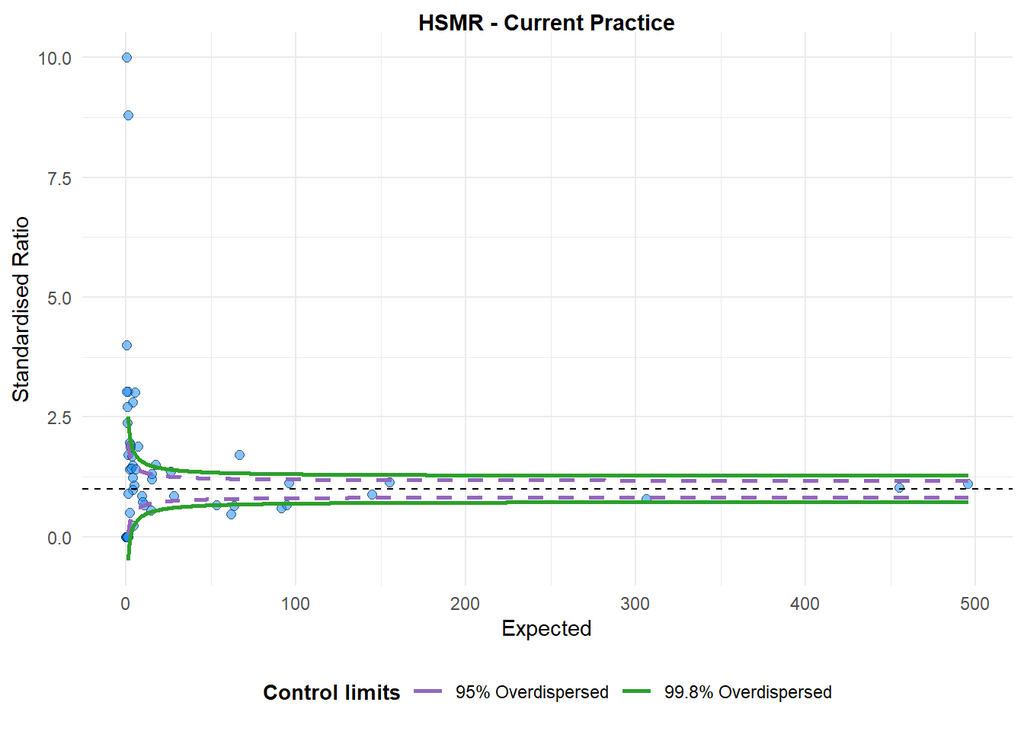

```r
library(tidyverse)
library(ggrepel)

#hsmr = readxl::read_excel("SMR_Test.xlsx")
hsmr = read.csv("SMR2.csv")

FunnelPlotR::funnel_plot(hsmr$numerator, hsmr$denominator,
                         hsmr$hospital_code, sr_method = "CQC",
                         label_outliers=FALSE,
                         title = "HSMR - Current Practice")
```

There are two issues with the above plot. Several hospitals with small expected counts exceed either the upper or lower control limits (there are 14 outliers above), a common occurence with overdispersed data. This leads to several hospitals being labelled as outliers, when it is more likely due to unmodelled dispersion in the data (i.e., a Type I error). Additionally, once the expected counts are sufficiently large, the control limits remain at a (more or less) fixed width. It would be expected that hospitals with larger expected counts should show smaller variation in their observed ratios, and so this fixed width may cause hospitals to fall within the control limits when they are truly outlying (i.e., Type II error).

The above example shows that constructing control limits assuming equal mean and variance, and then subsequently adjusting them, does not always sufficiently account for overdispersion.

An alternative then, is to construct the control limits without the assumption of equal mean and variance. This can be done by modelling the count data with a distribution that also models the extent of dispersion: the Negative-Binomial.

## Negative-Binomial Distribution

The Negative-Binomial is an attractive alternative to the Poisson as it does not assume an equal mean-variance relationship (like the Poisson).

The standard negative-binomial distribution is parameterised using :
$$y \sim NB(r,p)$$

These parameters are derived using the mean ($\mu$) and dispersion ($\phi$) of the distribution:
$$r = \phi \\
p = \frac{\phi}{\phi + \mu}$$

The mean of the distribution is given by:
$$E[y] = \mu$$

The variance of this distribution is given by:
$$Var[y] = \mu + \frac{\mu^2}{\phi}$$
Thus, the dispersion parameter $\phi$ allows the variance of the observations to be greater than the mean. Note also that as the dispersion parameter $\phi$ approaches $\infty$, the negative binomial distribution approaches the Poisson (i.e., the variance approaches the mean). This additional modelling of overdispersion is an attractive approach for constructing control limits for mortality data, as it allows for the limits to then represent the range within future observations should fall if they were as overdispersed as the present observations.

A simple and computationally inexpensive method to construct prediction intervals for the Negative-Binomial is through the use of Bayesian posterior-predictive distributions.

### Posterior-Predictive Distribution

As a brief background, the posterior distribution of a parameter represents the joint likelihood of the observed data given the parameter and the prior distribution of the parameter itself:
$$P(\theta | y) \sim P(y|\theta)P(\theta)$$
This posterior distribution encodes the current knowledge about a parameter, after updating the previous knowledge (the prior) with current observations (the likelihood).

The posterior-predictive distribution represents the expected distribution of future observations, given the current posterior distribution. This is derived by treating the new observations ($y_{new}$) as data, and the current posterior ($P(\theta|y)$) as the prior, and integrating across the parameter:
$$P(y_{new}|y) = \int_{\theta}P(y_{new}|\theta)P(\theta|y)d\theta$$

The resulting (posterior-predictive) distribution can then be used to construct intervals capturing the range within an expected proportion of future observations should fall (i.e., $1-\alpha$).

Generally speaking, the construction of posterior (and posterior-predictive) distributions can be computationally intensive - commonly requiring numerical approximation via Markov Chain Monte Carlo (MCMC) methods. However, through the appropriate use of likelihoods with conjugate prior distributions, these distributions can be derived in a closed-form. Given that, for quality improvement purposes, we are only interested in the intervals of the posterior-predictive distributions, these can be simply derived through either the normal approximation or quantiles.

### Negative-Binomial Prediction Intervals

To obtain a closed-form expression for the posterior-predictive distribution of the negative binomial, we’ll take advantage of the fact that it can be [reparameterised](https://gregorygundersen.com/blog/2019/09/16/poisson-gamma-nb/) as a Poisson distribution with a Gamma (shape and rate) prior.

That is, the negative-binomial:
$$y \sim NB(r,p)$$
Reiterating that:
$$r = \phi \\
p = \frac{\phi}{\phi + \mu}$$

Is equivalent to:
$$y \sim Poisson(\lambda) \\
\lambda \sim Gamma(r,\frac{p}{1-p})$$

The posterior distribution for $\lambda$ is then [given by](https://people.stat.sc.edu/Hitchcock/stat535slidesday18.pdf):

$$\lambda | y \sim Gamma(r + \Sigma{y_i}, \frac{p}{1-p} + N)$$

For the funnel plots, given that we will be constructing intervals for a range of denominator values, we consider each denominator as a singular observation:

$$\lambda | y \sim Gamma(r + y, \frac{p}{1-p} + 1)$$

We can then denote the hyperparameters of this posterior as:
$$a_1 = r + y$$

$$b_1 = \frac{p}{1-p} + 1$$
The posterior-predictive distribution of a Poisson with a Gamma prior [is itself a Negative-Binomial](https://en.wikipedia.org/wiki/Conjugate_prior#When_likelihood_function_is_a_discrete_distribution):
$$y_{new}|y \sim NB(a_1,\frac{1}{b_1+1})$$

With [mean and variance](https://people.stat.sc.edu/Hitchcock/stat535slidesday18.pdf):
$$E[y_{new}|y] = \frac{a_1}{b_1} \\
Var[y_{new}|y] = \frac{a_1}{b_1} + \frac{a_1}{b_1^2}$$

As shown above, the use of conjugate prior distributions allows for the moments (and quantiles) of this predictive distribution to be derived analytically, rather than needing to rely on MCMC methods. This has great value in a production context, allowing the control limits to be derived in a fraction of the time required to sample and post-process a full Bayesian model.

The only step remaining is the specification of the $\mu$ and $\phi$ parameters. Given that the aim is to construct control limits as overdispersed as the observed data, it’s a natural extension to then estimate this from the data. This can be done using maximum-likelihood. Note - this process of estimating a hyperparameter value from the observed data is commonly denoted ‘Empirical Bayes’.

We can then use this posterior-predictive distribution to construct the control limits through either the normal approximation ($E[y_{new}|y] \pm 3 *\sqrt{Var(y_{new}|y)}$), or by using the quantiles of the negative-binomial distribution.

### Worked Example

First we’ll estimate the parameters for the Negative-Binomial distribution. The naive approach would be to estimate these parameters using all observations. However, while some observed counts may not be large/extreme in and of themselves, they may be extreme when considered in combination with their respective expected count. The variation seen by these units with extreme ratios may be due to special cause variation rather than overdispersion. As such, if we account for the variation of these hospitals in the estimate of dispersion, then there is the risk of adjusting the control limits for special-cause variation rather than overdispersion.

To account for these issues, we instead estimate the model parameters using a truncated dataset. We will use the standard practice of truncating the upper and lower 10% of ratios:

```r
trunc_data = hsmr %>%
  mutate(pr = numerator / denominator) %>%
  filter(pr < quantile(pr, 0.9, na.rm=T) &
         pr > quantile(pr, 0.1, na.rm=T))
disp_fit =
  VGAM::vglm(numerator ~ 1, VGAM::negbinomial(), data=trunc_data) %>%
    VGAM::Coef() %>%
    as.numeric()

mu = disp_fit[1]
phi = disp_fit[2]

# Store the ranges of truncated data, for later plotting
xlims = range(trunc_data$denominator)
ylims = range(trunc_data$numerator/trunc_data$denominator)
```

Next we need a function to calculate the mean and variance of the posterior-predictive distribution for a given count and use that to calculate the control limits:

```r
lims_mvar = function(ynew,mu,phi) {
  # Transform mu and phi to NB parameters
  r = phi
  p = phi/(phi+mu)

  # Construct parameters of Gamma posterior
  a1 = r + ynew
  b1 = p/(1-p) + 1

  # Calculate Mean and SD
  m = a1/b1
  s = sqrt(a1/b1 + a1/(b1^2))

  # Return dataframe with approximate limits
  data.frame(
      ynew = ynew,
      phi = phi,
      type="Approximate",
      # Truncate lower limits at 0
      #  i.e., can't have negative counts
      "LCI_99" = max(m - 3.090232*s,0) / ynew,
      "LCI_95" = max(m - 1.959964*s,0) / ynew,
      "UCI_95" = (m + 1.959964*s) / ynew,
      "UCI_99" = (m + 3.090232*s) / ynew
  )
}
```

And the alternative to construct the control limits using quantiles:

```r
lims_quant = function(ynew,mu,phi) {
  # Transform mu and phi to NB parameters
  r = phi
  p = phi/(phi+mu)

  # Construct parameters of Gamma posterior
  a1 = r + ynew
  b1 = p/(1-p) + 1

  # Return dataframe with exact limits
  data.frame(
      ynew = ynew,
      phi = phi,
      type = "Exact",
      "LCI_99" = qnbinom(0.001, size = a1, prob = 1 / (1 + b1)) / ynew,
      "LCI_95" = qnbinom(0.025,  size = a1, prob = 1 / (1 + b1)) / ynew,
      "UCI_95" = qnbinom(0.975,  size = a1, prob = 1 / (1 + b1)) / ynew,
      "UCI_99" = qnbinom(0.999, size = a1, prob = 1 / (1 + b1)) / ynew
  )
}
```

We can then generate the control limits for the x-values:

```r
# Construct range of denominators to generate limits for
x_range = c(hsmr$denominator,seq.int(0,max(hsmr$denominator) + 10))

# Generate both approximate and exact limits
cnt_lims = full_join(map_dfr(x_range,lims_mvar,mu,phi),
                     map_dfr(x_range,lims_quant,mu,phi)) %>%
           distinct(ynew,type,.keep_all=TRUE)
```

And plot the results:

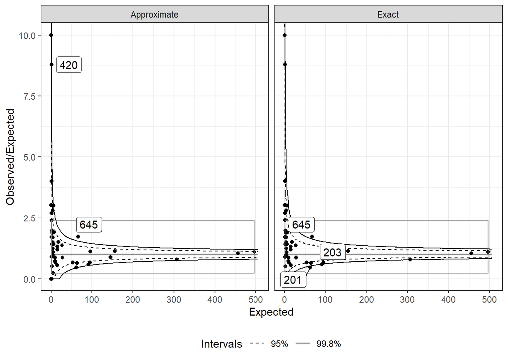

```r
left_join(hsmr,cnt_lims,by=c("denominator"="ynew")) %>%
    mutate(pr = numerator/denominator,
           outlier=ifelse(pr > UCI_99 | pr < LCI_99,hospital_code,NA)) %>%
    ggplot(aes(x=denominator,y=(numerator/denominator))) +
      geom_point(na.rm=T) +
      geom_segment(aes(y = 1, yend = 1,
                       x = min(denominator), xend = max(denominator) + 10)) +
      geom_line(data=cnt_lims,mapping=aes(x=ynew,y=LCI_99,linetype="99.8%")) +
      geom_line(data=cnt_lims,mapping=aes(x=ynew,y=UCI_99,linetype="99.8%")) +
      geom_line(data=cnt_lims,mapping=aes(x=ynew,y=LCI_95,linetype="95%")) +
      geom_line(data=cnt_lims,mapping=aes(x=ynew,y=UCI_95,linetype="95%")) +
      scale_linetype_manual(name="Intervals", values=c("dashed","solid")) +
      geom_rect(aes(xmin=xlims[1],xmax=xlims[2],ymin=ylims[1],ymax=ylims[2]),
                fill=NA,colour="gray50") +
      coord_cartesian(ylim=c(0,max(hsmr$numerator/hsmr$denominator,na.rm=T))) +
      geom_label_repel(aes(label=outlier),inherit.aes = TRUE) +
      labs(y="Observed/Expected", x ="Expected") +
      theme_bw() +
      theme(legend.position="bottom") +
      facet_grid(~type)
```

Note that the grey rectangle indicates the region of the data that was used to estimate dispersion.

If we again inspect the results of the funnel plot generated by the `FunnelPlotR` package:

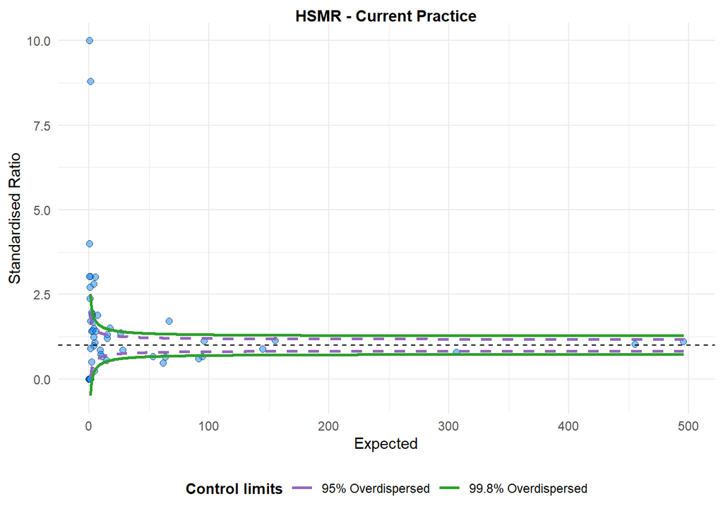

```r
FunnelPlotR::funnel_plot(hsmr$numerator, hsmr$denominator,
                         hsmr$hospital_code, sr_method = "CQC",
                         label_outliers=FALSE,
                         title = "HSMR - Current Practice")
```

This likely due to high levels of overdispersion in the data. If we inspect the dispersion parameter:

```r
cnt_lims$phi[1]
```

```
## [1] 0.4547018
```

Noting that $\phi = \infty$ results in the Poisson distribution, this small value indicates large overdispersion which appears markedly better handled by the posterior predictive intervals.